# Model Performance - rpart

Hakan Egeli

Soumyendu Sarkar

April 24, 2018

# Decision Tree Model

Similart to building our intial linear model, we have examined the relevance of all the dependent variables. We identified the most relevant variables so that we can build our initial decision tree model accordingly.

```
## Call:
## rpart(formula = CreditLimit ~ ., data = dataset_train)
##   n= 1401
##
##            CP nsplit rel error    xerror       xstd
## 1  0.49009759      0 1.0000000 1.0012435 0.13506302
## 2  0.10494278      1 0.5099024 0.5680393 0.08577041
## 3  0.03073976      2 0.4049596 0.4663767 0.09028672
## 4  0.03055132      3 0.3742199 0.4789546 0.09013241
## 5  0.02956978      4 0.3436686 0.4750873 0.09010327
## 6  0.02633803      5 0.3140988 0.4446613 0.08838201
## 7  0.01690643      6 0.2877607 0.4289728 0.08946854
## 8  0.01102148      8 0.2539479 0.4252393 0.09091017
## 9  0.01015749      9 0.2429264 0.4239214 0.09030920
## 10 0.01000000     11 0.2226114 0.4208922 0.09031590
##
## Variable importance
##                     JBTRating          AvgDaysOfPayCategory
##                            61                             5
##             CreditLimitLocked       DesignBandSalesLast12Mo
##                             4                             4
##                  AvgDaysOfPay                   SalesLastYr
##                             4                             3
##            TotalSalesLast12Mo AlternativeMetalSalesLast12Mo
##                             2                             2
##        MedianIncomeHouseholds                SalesCurrentYr
##                             2                             2
##        PlainBandSalesLast12Mo                MedianEarnings
##                             2                             1
##               TotalHouseholds               TotalPopulation
##                             1                             1
##         NumberOfJewelryStores                 AvgAmtPastDue
##                             1                             1
##       RuralUrbanContinuumCode                MaxDaysPastDue
##                             1                             1
##        NumberOfStoreLocations
##                             1
##
## Node number 1: 1401 observations,    complexity param=0.4900976
##   mean=3615.453, MSE=1.948975e+07
```

[output cut: 180 more lines]

```
##
## Node number 21: 440 observations
##   mean=4960.227, MSE=239895.4
##
## Node number 38: 17 observations
##   mean=5441.176, MSE=1.817301e+07
##
## Node number 39: 11 observations
##   mean=15818.18, MSE=1.286942e+08
##
## Node number 40: 94 observations
##   mean=2739.362, MSE=3902812
##
## Node number 41: 8 observations
##   mean=9250, MSE=2.31875e+07
```

We also did a quick plot of our decision tree to visualize the model’s output.

[figure not shown]

### What is the best cp to use?

Examining the model results, we wanted to determine the best cp value to use for our model to optimize it. To do that, we did a plot of the cp values and extracted the min cp value.

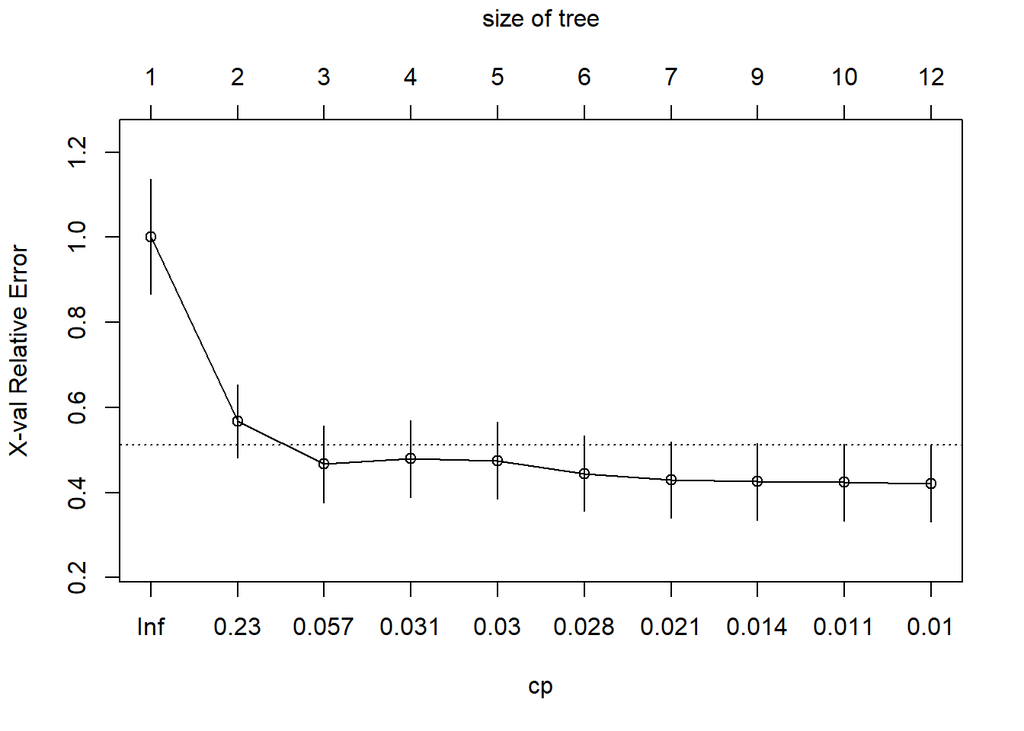

```
## Min cp value:  0.01
```

### What are the most relevant variables?

```
##                     JBTRating          AvgDaysOfPayCategory
##                   17624147530                    1427989851
##             CreditLimitLocked       DesignBandSalesLast12Mo
##                    1193255286                    1148472475
##                  AvgDaysOfPay                   SalesLastYr
##                    1047962645                     877434526
##            TotalSalesLast12Mo AlternativeMetalSalesLast12Mo
##                     723008569                     628449619
##        MedianIncomeHouseholds                SalesCurrentYr
##                     555680124                     489979597
##        PlainBandSalesLast12Mo                MedianEarnings
##                     470398677                     432195652
##               TotalHouseholds               TotalPopulation
##                     370453416                     370453416
##         NumberOfJewelryStores                 AvgAmtPastDue
##                     308711180                     297931404
##       RuralUrbanContinuumCode                MaxDaysPastDue
##                     246968944                     196135509
##        NumberOfStoreLocations      DiamondBandSalesLast12Mo
##                     196135509                     121940368
##                 MaxAmtPastDue        JewelryStoreSalesState
##                     121841615                      91896213
##             BuyingGroupMember     MedianRetailTradeEarnings
##                      17772225                       5924075
```

We took a close look at the most relevant variables and we have eliminated JBT Rating (as stated in our linear model, we want to predict credit limits for the customers that do not have a credit rating so we do not want this variable to influence our model), Credit Limit Lock, AvgDaysOfPay (Avg Days of Pay Category is already included), AvgAmtPastDue (we felt like this might not be a variable that we can obtain from a new customer), MaxDaysPastDue (again, this might not be a parameter that we can obtain from a potential new customer), and we ended up with the following:

```r
model <- rpart(CreditLimit ~ AvgDaysOfPayCategory + DesignBandSalesLast12Mo + SalesLastYr + TotalSalesLast12Mo + AlternativeMetalSalesLast12Mo + MedianIncomeHouseholds + SalesCurrentYr + PlainBandSalesLast12Mo + MedianEarnings + TotalHouseholds + TotalPopulation + NumberOfJewelryStores + RuralUrbanContinuumCode, data = dataset_train, control = rpart.control(cp = 0.0169))
```

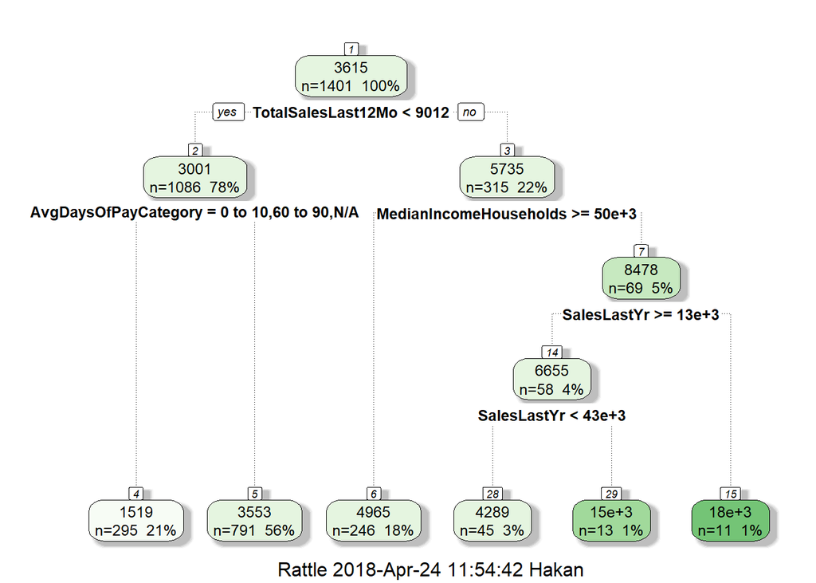

```
## Call:
## rpart(formula = CreditLimit ~ AvgDaysOfPayCategory + DesignBandSalesLast12Mo +
##     SalesLastYr + TotalSalesLast12Mo + AlternativeMetalSalesLast12Mo +
##     MedianIncomeHouseholds + SalesCurrentYr + PlainBandSalesLast12Mo +
##     MedianEarnings + TotalHouseholds + TotalPopulation + NumberOfJewelryStores +
##     RuralUrbanContinuumCode, data = dataset_train, control = rpart.control(cp = 0.0169))
##   n= 1401
##
##           CP nsplit rel error    xerror      xstd
## 1 0.06685409      0 1.0000000 1.0005736 0.1351003
## 2 0.03431858      1 0.9331459 0.9601879 0.1287535
## 3 0.03258027      4 0.8233382 0.9862806 0.1292651
## 4 0.01690000      5 0.7907580 0.9866348 0.1293023
##
## Variable importance
##                   SalesLastYr            TotalSalesLast12Mo
##                            24                            21
##                SalesCurrentYr       DesignBandSalesLast12Mo
##                            11                            11
##        PlainBandSalesLast12Mo AlternativeMetalSalesLast12Mo
##                             9                             8
##          AvgDaysOfPayCategory        MedianIncomeHouseholds
##                             6                             4
##                MedianEarnings               TotalHouseholds
##                             2                             1
##         NumberOfJewelryStores               TotalPopulation
##                             1                             1
##       RuralUrbanContinuumCode
##                             1
##
## Node number 1: 1401 observations,    complexity param=0.06685409
##   mean=3615.453, MSE=1.948975e+07
##   left son=2 (1086 obs) right son=3 (315 obs)
##   Primary splits:
##       TotalSalesLast12Mo      < 9012     to the left,  improve=0.06685409, (0 missing)
##       AvgDaysOfPayCategory    splits as  LRRLLL,       improve=0.05847212, (0 missing)
##       PlainBandSalesLast12Mo  < 3686.5   to the left,  improve=0.05653936, (0 missing)
##       SalesLastYr             < 39910    to the left,  improve=0.05136559, (0 missing)
##       DesignBandSalesLast12Mo < 4044.5   to the left,  improve=0.05090694, (0 missing)
##   Surrogate splits:
```

[output cut: 70 more lines]

```
##   Surrogate splits:
##       TotalSalesLast12Mo            < 24160    to the left,  agree=0.931, adj=0.692, (0 split)
##       DesignBandSalesLast12Mo       < 14178    to the left,  agree=0.862, adj=0.385, (0 split)
##       AlternativeMetalSalesLast12Mo < 9948     to the left,  agree=0.862, adj=0.385, (0 split)
##       SalesCurrentYr                < 23419.5  to the left,  agree=0.862, adj=0.385, (0 split)
##       PlainBandSalesLast12Mo        < 15118    to the left,  agree=0.845, adj=0.308, (0 split)
##
## Node number 15: 11 observations
##   mean=18090.91, MSE=1.706281e+08
##
## Node number 28: 45 observations
##   mean=4288.889, MSE=2.473877e+07
##
## Node number 29: 13 observations
##   mean=14846.15, MSE=1.187456e+08
```

### Backward Elimitaion to find the significant coefficients

We perfomed a Backward Elimination; remove the least relevant (highest p) variables (MedianEarnings, TotalHouseholds, NumberOfJewelryStores, TotalPopulation, RuralUrbanContinuumCode) and rebuild the model.

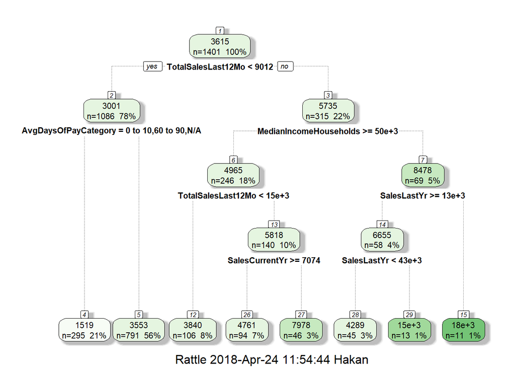

```
##
## Regression tree:
## rpart(formula = CreditLimit ~ DesignBandSalesLast12Mo + AvgDaysOfPayCategory +
##     SalesLastYr + TotalSalesLast12Mo + AlternativeMetalSalesLast12Mo +
##     SalesCurrentYr + PlainBandSalesLast12Mo + MedianIncomeHouseholds,
##     data = dataset_train, control = rpart.control(cp = 0.01))
##
## Variables actually used in tree construction:
## [1] AvgDaysOfPayCategory   MedianIncomeHouseholds SalesCurrentYr
## [4] SalesLastYr            TotalSalesLast12Mo
##
## Root node error: 2.7305e+10/1401 = 19489749
##
## n= 1401
##
##         CP nsplit rel error  xerror    xstd
## 1 0.066854      0   1.00000 1.00140 0.13516
## 2 0.034319      1   0.93315 1.00017 0.13252
## 3 0.032580      4   0.82334 0.98908 0.13090
## 4 0.010178      5   0.79076 0.96459 0.12833
## 5 0.010000      7   0.77040 0.95298 0.12451
```

```
## Relative Error: 19489749 * 0.77040 =  15014903
```

### Credit Limit as a class

We wanted to see the impact on the decision tree model if we converted our Credit Limit values from numerical continious values to categorical values. So we set a new field and a copy of our training set and factorized the Credit Limit field.

```r
dataset_train_alt <- dataset_train

dataset_train_alt$CreditLimit <- factor(dataset_train_alt$CreditLimit)

model <- rpart(CreditLimit ~ DesignBandSalesLast12Mo + AvgDaysOfPayCategory + SalesLastYr + TotalSalesLast12Mo + AlternativeMetalSalesLast12Mo + SalesCurrentYr + PlainBandSalesLast12Mo + MedianIncomeHouseholds, data = dataset_train_alt, control = rpart.control(cp = 0.002), method="class")
```

[figure not shown]

# Model Performance

We built a confusion matrix to evaluate this model’s performance

```r
predictions <- predict(model, dataset_train_alt, type = "class")

cm <- confusionMatrix(dataset_train_alt$CreditLimit, predictions)
```

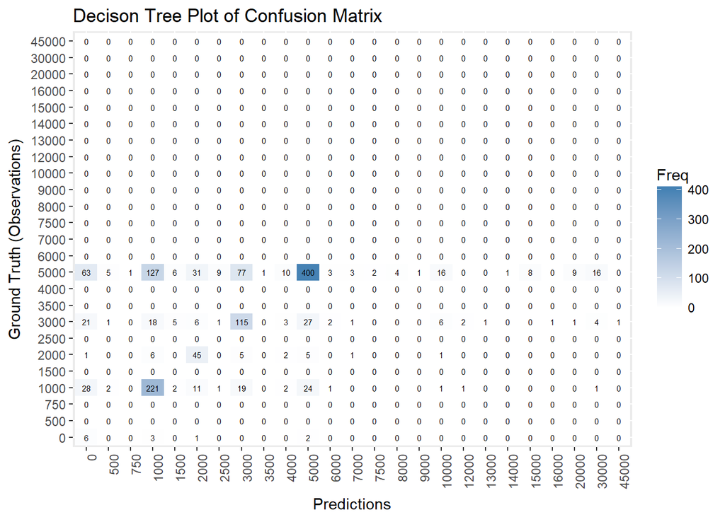

```
##       Accuracy          Kappa  AccuracyLower  AccuracyUpper   AccuracyNull
##      0.5617416      0.3974274      0.5352966      0.5879272      0.5660243
## AccuracyPValue  McnemarPValue
##      0.6373582            NaN
```

```
##              Sensitivity Specificity Pos Pred Value Neg Pred Value
## Class: 0       0.5000000   0.9186465     0.05042017      0.9953198
## Class: 500            NA   0.9942898             NA             NA
## Class: 750            NA   0.9992862             NA             NA
## Class: 1000    0.7038217   0.8583257     0.58933333      0.9093567
## Class: 1500           NA   0.9907209             NA             NA
## Class: 2000    0.6818182   0.9632959     0.47872340      0.9839327
## Class: 2500           NA   0.9921485             NA             NA
## Class: 3000    0.5324074   0.9147679     0.53240741      0.9147679
## Class: 3500           NA   0.9992862             NA             NA
## Class: 4000           NA   0.9878658             NA             NA
## Class: 5000    0.5044136   0.9046053     0.87336245      0.5832450
## Class: 6000           NA   0.9957173             NA             NA
## Class: 7000           NA   0.9964311             NA             NA
## Class: 7500           NA   0.9985724             NA             NA
## Class: 8000           NA   0.9971449             NA             NA
## Class: 9000           NA   0.9992862             NA             NA
## Class: 10000          NA   0.9828694             NA             NA
## Class: 12000          NA   0.9978587             NA             NA
## Class: 13000          NA   0.9992862             NA             NA
## Class: 14000          NA   0.9992862             NA             NA
## Class: 15000          NA   0.9942898             NA             NA
## Class: 16000          NA   0.9992862             NA             NA
## Class: 20000          NA   0.9928622             NA             NA
## Class: 30000          NA   0.9850107             NA             NA
## Class: 45000          NA   0.9992862             NA             NA
##               Precision    Recall         F1 Prevalence Detection Rate
## Class: 0     0.05042017 0.5000000 0.09160305 0.00856531    0.004282655
## Class: 500   0.00000000        NA         NA 0.00000000    0.000000000
## Class: 750   0.00000000        NA         NA 0.00000000    0.000000000
## Class: 1000  0.58933333 0.7038217 0.64150943 0.22412562    0.157744468
## Class: 1500  0.00000000        NA         NA 0.00000000    0.000000000
## Class: 2000  0.47872340 0.6818182 0.56250000 0.04710921    0.032119914
## Class: 2500  0.00000000        NA         NA 0.00000000    0.000000000
## Class: 3000  0.53240741 0.5324074 0.53240741 0.15417559    0.082084226
## Class: 3500  0.00000000        NA         NA 0.00000000    0.000000000
## Class: 4000  0.00000000        NA         NA 0.00000000    0.000000000
## Class: 5000  0.87336245 0.5044136 0.63948841 0.56602427    0.285510350
## Class: 6000  0.00000000        NA         NA 0.00000000    0.000000000
## Class: 7000  0.00000000        NA         NA 0.00000000    0.000000000
```

[output cut: 23 more lines]

```
## Class: 5000          0.3269093505         0.7045094
## Class: 6000          0.0042826552                NA
## Class: 7000          0.0035688794                NA
## Class: 7500          0.0014275517                NA
## Class: 8000          0.0028551035                NA
## Class: 9000          0.0007137759                NA
## Class: 10000         0.0171306210                NA
## Class: 12000         0.0021413276                NA
## Class: 13000         0.0007137759                NA
## Class: 14000         0.0007137759                NA
## Class: 15000         0.0057102070                NA
## Class: 16000         0.0007137759                NA
## Class: 20000         0.0071377587                NA
## Class: 30000         0.0149892934                NA
## Class: 45000         0.0007137759                NA
```

```
##
## Classification tree:
## rpart(formula = CreditLimit ~ DesignBandSalesLast12Mo + AvgDaysOfPayCategory +
##     SalesLastYr + TotalSalesLast12Mo + AlternativeMetalSalesLast12Mo +
##     SalesCurrentYr + PlainBandSalesLast12Mo + MedianIncomeHouseholds,
##     data = dataset_train_alt, method = "class", control = rpart.control(cp = 0.002))
##
## Variables actually used in tree construction:
## [1] AlternativeMetalSalesLast12Mo AvgDaysOfPayCategory
## [3] DesignBandSalesLast12Mo       MedianIncomeHouseholds
## [5] PlainBandSalesLast12Mo        SalesCurrentYr
## [7] SalesLastYr
##
## Root node error: 943/1401 = 0.67309
##
## n= 1401
##
##           CP nsplit rel error  xerror     xstd
## 1  0.1675504      0   1.00000 1.00000 0.018619
## 2  0.0381760      1   0.83245 0.83775 0.019684
## 3  0.0095440      2   0.79427 0.80064 0.019786
## 4  0.0056557      3   0.78473 0.79109 0.019804
## 5  0.0048780      9   0.74337 0.79109 0.019804
## 6  0.0042418     16   0.70732 0.80064 0.019786
## 7  0.0031813     17   0.70308 0.78579 0.019813
## 8  0.0024744     19   0.69671 0.80276 0.019782
## 9  0.0021209     31   0.66384 0.81336 0.019757
## 10 0.0020000     37   0.65111 0.81654 0.019748
```

```
## Relative Error: 0.65111 * 0.67309 =  0.4382556
```

Even though the model where we have converted the **Credit Limit** to a categorical value performed better than the one using continuous values, the Accuracy of the better model is very low. We will next try to take the variables actually used in this decision tree and try them on a linear model next to see if there can be any improvement made to the liner model based on what we learned from the decision tree model.